# Final Challenge Problem

Laura Ye

March 28, 2018

## Problem 1

Using birth_data.csv and caret-based methods, build a model that determines whether a baby is at risk, i.e., needs immediate emergency care or extra medical attention immediately upon birth.

### About the Data

Let’s take a look by loading the data into our workspace.

```r
# Load data into workspace
birth_data <- read_csv("birth_data.csv")

# Number of observations and variables
dim(birth_data)
```

```
[1] 26313    15
```

```r
#glimpse of data set
glimpse(birth_data)
```

```
Observations: 26,313
Variables: 15
$ PWGT          <int> 155, 140, 151, 118, 134, 117, 160, 98, 132, 135,...
$ UPREVIS       <int> 14, 13, 15, 4, 11, 18, 1, 8, 15, 7, 4, 10, 6, 14...
$ CIG_REC       <lgl> FALSE, FALSE, FALSE, FALSE, FALSE, FALSE, TRUE, ...
$ GESTREC3      <chr> ">= 37 weeks", ">= 37 weeks", ">= 37 weeks", ">=...
$ DPLURAL       <chr> "single", "single", "single", "single", "single"...
$ ULD_MECO      <lgl> TRUE, FALSE, FALSE, FALSE, FALSE, TRUE, FALSE, F...
$ ULD_PRECIP    <lgl> FALSE, FALSE, FALSE, FALSE, FALSE, FALSE, FALSE,...
$ ULD_BREECH    <lgl> FALSE, FALSE, FALSE, FALSE, FALSE, FALSE, FALSE,...
$ URF_DIAB      <lgl> FALSE, FALSE, FALSE, FALSE, FALSE, FALSE, FALSE,...
$ URF_CHYPER    <lgl> FALSE, FALSE, FALSE, FALSE, FALSE, FALSE, FALSE,...
$ URF_PHYPER    <lgl> FALSE, FALSE, FALSE, FALSE, FALSE, FALSE, FALSE,...
$ URF_ECLAM     <lgl> FALSE, FALSE, FALSE, FALSE, FALSE, FALSE, FALSE,...
$ atRisk        <lgl> FALSE, FALSE, FALSE, FALSE, FALSE, FALSE, FALSE,...
$ DBWT          <int> 3714, 3715, 3447, 3175, 4038, 3410, 2981, 3065, ...
$ ORIGRANDGROUP <int> 2, 4, 2, 6, 10, 7, 2, 7, 9, 6, 2, 0, 9, 1, 6, 3,...
```

The predictor variables contain the following information:

| Column Name | Data Type | Description |
| --- | --- | --- |
| atRisk | Logical | likely to need immediate emergency extra medical attention upon birth |
| PWGT | Numeric | Mother’s prepregnancy weight |
| UPREVIS | Numeric (integer) | Number of prenatal medical visits |
| CIG_REC | Logical | TRUE if smoker; FALSE otherwise |
| GESTREC3 | Categorical | Two categories: <37 weeks (premature) and >=37 weeks |
| DPLURAL | Categorical | Birth plurality, three categories: single/twin/triplet+ |
| ULD_MECO | Logical | TRUE if moderate/heavy fecal staining of amniotic fluid |
| ULD_PRECIP | Logical | TRUE for unusually short labor (< three hours) |
| ULD_BREECH | Logical | TRUE for breech (pelvis first) birth position |
| URF_DIAB | Logical | TRUE if mother is diabetic |
| URF_CHYPER | Logical | TRUE if mother has chronic hypertension |
| URF_PHYPER | Logical | TRUE if mother has pregnancy-related hypertension |
| URF_ECLAM | Logical | TRUE if mother experienced eclampsia: pregnancy-related seizures |

### Preparing the Data

In this step I will prepare the data for our machine learning models by cleaning the data and also splitting the data into a train and test set.

#### Cleaning the Data

To clean the data set, I will check for missing data, transform categorical variables, and also remove zero and near-zero variance data.

##### Missing Data

Let’s see if there’s any missing data.

```r
# Number of cells with missing data (NULLs)
sum(is.na(birth_data))
```

```
[1] 0
```

Since there aren’t any missing values in this data set, I will move on to the next step of data cleaning.

##### Categorical Data

Categorical variables with more than 2 levels like DPLURAL will be converted to dummy variables using one-hot-encoding. Categorical variables with only 2 levels will be factorized as is.

```r
# convert GESTREC3 to factor
birth_data_clean <- birth_data %>%
  mutate(GESTREC3 = factor(GESTREC3))

# convert outcome to a factor
birth_data_clean <- birth_data_clean %>%
  mutate(atRisk = factor(as.numeric(atRisk)))

# convert DPLURAL using one-hot-encoding
dplural_dmy <- dummyVars(" ~ DPLURAL", data=birth_data_clean, fullRank = T)
dplural_vals <- data.frame(predict(dplural_dmy, newdata=birth_data_clean))

# add encoded DPLURAL to data frame
birth_data_clean <- birth_data_clean %>%
  add_column(DPLURALtriplet = as.integer(dplural_vals$DPLURALtriplet.or.higher),
             DPLURALtwin = as.integer(dplural_vals$DPLURALtwin)) %>%
  select(-DPLURAL)
```

The data frame is now cleaned and ready for further processing.

```r
# final state of cleaned data set
glimpse(birth_data_clean)
```

```
Observations: 26,313
Variables: 16
$ PWGT           <int> 155, 140, 151, 118, 134, 117, 160, 98, 132, 135...
$ UPREVIS        <int> 14, 13, 15, 4, 11, 18, 1, 8, 15, 7, 4, 10, 6, 1...
$ CIG_REC        <lgl> FALSE, FALSE, FALSE, FALSE, FALSE, FALSE, TRUE,...
$ GESTREC3       <fctr> >= 37 weeks, >= 37 weeks, >= 37 weeks, >= 37 w...
$ ULD_MECO       <lgl> TRUE, FALSE, FALSE, FALSE, FALSE, TRUE, FALSE, ...
$ ULD_PRECIP     <lgl> FALSE, FALSE, FALSE, FALSE, FALSE, FALSE, FALSE...
$ ULD_BREECH     <lgl> FALSE, FALSE, FALSE, FALSE, FALSE, FALSE, FALSE...
$ URF_DIAB       <lgl> FALSE, FALSE, FALSE, FALSE, FALSE, FALSE, FALSE...
$ URF_CHYPER     <lgl> FALSE, FALSE, FALSE, FALSE, FALSE, FALSE, FALSE...
$ URF_PHYPER     <lgl> FALSE, FALSE, FALSE, FALSE, FALSE, FALSE, FALSE...
$ URF_ECLAM      <lgl> FALSE, FALSE, FALSE, FALSE, FALSE, FALSE, FALSE...
$ atRisk         <fctr> 0, 0, 0, 0, 0, 0, 0, 0, 0, 0, 0, 0, 0, 0, 0, 0...
$ DBWT           <int> 3714, 3715, 3447, 3175, 4038, 3410, 2981, 3065,...
$ ORIGRANDGROUP  <int> 2, 4, 2, 6, 10, 7, 2, 7, 9, 6, 2, 0, 9, 1, 6, 3...
$ DPLURALtriplet <int> 0, 0, 0, 0, 0, 0, 0, 0, 0, 0, 0, 0, 0, 0, 0, 0,...
$ DPLURALtwin    <int> 0, 0, 0, 0, 0, 0, 0, 0, 0, 0, 0, 0, 0, 0, 0, 0,...
```

##### Zero and Near-Zero Variance Data

Zero and Near-Zero Variance Data will be removed using caret’s preProcess methods.

```r
# Preprocess data for zv and nzv
birth_data_prep <- preProcess(birth_data_clean, methods=c("zv", "nzv"))
birth_data_cleaned <- predict(birth_data_prep, newdata=birth_data_clean)

# Compare dimensions
dim(birth_data_clean)
```

```
[1] 26313    16
```

```r
dim(birth_data_cleaned)
```

```
[1] 26313    16
```

Since the dimensions of the preProcessed data and the original data set are the same, there are no columns with zero and near-zero variance data.

#### Splitting the Data

The data is now ready to be split into a train (70%), and test (30%) set. The train set is what we will use to train models. The test set is what we will use to select the best tuned model and also the best model overall.

```r
set.seed(3)

# split data using caret::createDataPartition
split <- createDataPartition(birth_data_clean$atRisk, times = 1, p=0.7, list=FALSE)

# assign observations based on split
train <- birth_data_clean[split,]
test <- birth_data_clean[-split,]

print("Percentage of rows in training set:")
```

```
[1] "Percentage of rows in training set:"
```

```r
round(nrow(train)/nrow(birth_data_clean)*100, 2)
```

```
[1] 70
```

### Logistic Regression

For logistic regression, we will use the training set to fit a general logistic regression model and then evaluate using the test set. For logistic regression, we will not be tuning this model since there are no parameters to tune.

First, fit a logistic regression model.

```r
# generate glm model
glm_fit <- train(atRisk ~ .,
                 data = train,
                 method="glm",
                 family="binomial")
```

Let’s take a look at how it performed against the test set.

```r
# generate predictions based on glm model
glm_pred <- predict(glm_fit, newdata=test)

# extract accuracy from confusionMatrix
caret::confusionMatrix(test$atRisk, glm_pred)$overall["Accuracy"]
```

```
Accuracy
0.981756
```

```r
# determine AUC
print("AUC is:")
```

```
[1] "AUC is:"
```

```r
ModelMetrics::auc(test$atRisk, glm_pred)
```

```
[1] 0.5
```

Even without tuning, this model is very accurate. However AUC is low.

### Gradient-Boosting Machine (GBM) model

For GBM model, there are four tuning parameters that we can use:

- n.trees = number of boosting iterations
- interaction.depth = max tree depth
- shrinkage = shrinkage
- n.minobsinnode = minimum observations in node

The train function in caret using the gbm method does some parameter tuning already:

```r
# Generate gbm model
gbm_fit <- train(atRisk ~ .,
                 data=train,
                 method="gbm",
                 verbose = FALSE)

print(gbm_fit)
```

```
Stochastic Gradient Boosting

18420 samples
   15 predictor
    2 classes: '0', '1'

No pre-processing
Resampling: Bootstrapped (25 reps)
Summary of sample sizes: 18420, 18420, 18420, 18420, 18420, 18420, ...
Resampling results across tuning parameters:

  interaction.depth  n.trees  Accuracy   Kappa
  1                   50      0.9821954  0.1333393
  1                  100      0.9821895  0.1255106
  1                  150      0.9821836  0.1271493
  2                   50      0.9820065  0.1324439
  2                  100      0.9819178  0.1411943
  2                  150      0.9818120  0.1445106
  3                   50      0.9818115  0.1407730
  3                  100      0.9816702  0.1456192
  3                  150      0.9816529  0.1509781

Tuning parameter 'shrinkage' was held constant at a value of 0.1

Tuning parameter 'n.minobsinnode' was held constant at a value of 10
Accuracy was used to select the optimal model using the largest value.
The final values used for the model were n.trees = 50, interaction.depth
 = 1, shrinkage = 0.1 and n.minobsinnode = 10.
```

We can still test out other parameters to see what combination of tuning parameters would yield a better accuracy than the accuracy from the model above:

```r
# Set parameters to test
n.trees <- 50
shrinkage <- seq(0.05, 0.15, 0.05)
n.minobsinnode <- c(5, 10, 15)
interaction.depth <- c(1, 2)

# Create hyperparameter grid for grid search
gbm_grid <- expand.grid(n.trees = n.trees,
                        shrinkage = shrinkage,
                        n.minobsinnode = n.minobsinnode,
                        interaction.depth = interaction.depth)

# Train gbm model using grid search
gbm_fit2 <- train(atRisk ~ .,
                  data = train,
                  method = "gbm",
                  tuneGrid = gbm_grid,
                  verbose = FALSE)

print(gbm_fit2)
```

```
Stochastic Gradient Boosting

18420 samples
   15 predictor
    2 classes: '0', '1'

No pre-processing
Resampling: Bootstrapped (25 reps)
Summary of sample sizes: 18420, 18420, 18420, 18420, 18420, 18420, ...
Resampling results across tuning parameters:

  shrinkage  interaction.depth  n.minobsinnode  Accuracy   Kappa
  0.05       1                   5              0.9823341  0.1221977
  0.05       1                  10              0.9821852  0.1184106
  0.05       1                  15              0.9820731  0.1318306
  0.05       2                   5              0.9823925  0.1271382
  0.05       2                  10              0.9823093  0.1319835
  0.05       2                  15              0.9821445  0.1336834
  0.10       1                   5              0.9821668  0.1230907
  0.10       1                  10              0.9822151  0.1229214
  0.10       1                  15              0.9820140  0.1317685
  0.10       2                   5              0.9820371  0.1374919
  0.10       2                  10              0.9820964  0.1424526
  0.10       2                  15              0.9818893  0.1344796
  0.15       1                   5              0.9822618  0.1273200
  0.15       1                  10              0.9822276  0.1241604
  0.15       1                  15              0.9819249  0.1367225
  0.15       2                   5              0.9818427  0.1406411
  0.15       2                  10              0.9816359  0.1316465
  0.15       2                  15              0.9816887  0.1358308

Tuning parameter 'n.trees' was held constant at a value of 50
Accuracy was used to select the optimal model using the largest value.
The final values used for the model were n.trees = 50, interaction.depth
 = 2, shrinkage = 0.05 and n.minobsinnode = 5.
```

Let’s now evaluate the accuracy for the test set.

```r
# Predict values for test set
gbm_pred <- predict(gbm_fit2, newdata=test)

# extract accuracy from confusionMatrix
caret::confusionMatrix(test$atRisk, gbm_pred)$overall["Accuracy"]
```

```
 Accuracy
0.9828962
```

```r
# Calculate AUC
print("AUC is:")
```

```
[1] "AUC is:"
```

```r
ModelMetrics::auc(test$atRisk, gbm_pred)
```

```
[1] 0.5346577
```

Accuracy and AUC are slightly higher than Logistic Regression, but the improvement is not significant.

### Performance Evaluation

Here is a summary of the two model performances:

[output not shown]

The tuned GBM model slightly outperforms logistic regression model by 0.1% in accuracy.

## Problem 2

Use ocdata.csv to solve Problems 2A and 2B.

### About the Data

ocdata.csv contains the following fields:

```r
# Load data into workspace
oc_data <- read_csv("ocdata.csv")

# Get column names
names(oc_data)
```

```
[1] "education" "income"    "women"     "prestige"  "census"    "type"
```

Income is the response variable that we’d like to predict.

```r
# Get dimension of data
dim(oc_data)
```

```
[1] 102   6
```

This data set has about 102 observations.

### Preparing the Data

To clean the data set, I will check for missing data, transform categorical variables, and also remove zero and near-zero variance data.

#### Missing Data

Let’s see if there’s any missing data.

```r
# Number of cells with missing data (NULLs)
sum(is.na(oc_data))
```

```
[1] 4
```

Where are the missing data? Let’s look at the number of missing data by column.

```r
# Number of cells of missing data by columns
colSums(is.na(oc_data))
```

```
education    income     women  prestige    census      type
        0         0         0         0         0         4
```

For now, the missing data will be left alone, since Problem 2A does not use the type variable to predict income.

#### Cleaning the Data

Let’s take a look at the data types that we have.

```r
glimpse(oc_data)
```

```
Observations: 102
Variables: 6
$ education <dbl> 13.11, 12.26, 12.77, 11.42, 14.62, 15.64, 15.09, 15....
$ income    <int> 12351, 25879, 9271, 8865, 8403, 11030, 8258, 14163, ...
$ women     <dbl> 11.16, 4.02, 15.70, 9.11, 11.68, 5.13, 25.65, 2.69, ...
$ prestige  <dbl> 68.8, 69.1, 63.4, 56.8, 73.5, 77.6, 72.6, 78.1, 73.1...
$ census    <int> 1113, 1130, 1171, 1175, 2111, 2113, 2133, 2141, 2143...
$ type      <chr> "prof", "prof", "prof", "prof", "prof", "prof", "pro...
```

To clean the data, the type variable will be converted to a factor. Other variables will be left as is.

```r
# Factorize type column
oc_data_clean <- oc_data %>%
  mutate(type = factor(oc_data$type))
```

This way, the type variable can be treated as a categorical variable.

##### Zero and Near-Zero Variance Data

Zero and Near-Zero Variance Data will be removed using caret’s preProcess methods.

```r
# Preprocess data for zv and nzv
oc_data_prep <- preProcess(oc_data_clean, methods=c("zv", "nzv"))
oc_data_cleaned <- predict(oc_data_prep, newdata=oc_data_clean)

# Compare dimensions
dim(oc_data_clean)
```

```
[1] 102   6
```

```r
dim(oc_data_cleaned)
```

```
[1] 102   6
```

Since the dimensions of the preProcessed data and the original data set are the same, there are no columns with zero and near-zero variance data.

#### Splitting the Data

The data is now ready to be split into a train (70%), and test (30%) set. The train set is what we will use to train models. The test set is what we will use to select the best tuned model and also the best model overall.

```r
set.seed(3)

# split data using caret::createDataPartition
split <- createDataPartition(oc_data_clean$income, times = 1, p=0.7, list=FALSE)

# assign observations based on split
train <- oc_data_clean[split,]
test <- oc_data_clean[-split,]

print("Percentage of rows in training set:")
```

```
[1] "Percentage of rows in training set:"
```

```r
round(nrow(train)/nrow(oc_data_clean)*100, 2)
```

```
[1] 72.55
```

### Problem 2A

Fit a *univariate* OLSR (Ordinary Least Squares Regression) model, adhering to OLSR assumptions, predicting **income from prestige** only.

```r
# Fit to univariate OLSR
lm_fit <- lm(income ~ prestige, data=oc_data_clean)

# Predict values for test
lm_pred <- predict(lm_fit, newdata=test)

# Calculate RMSE
rmse(actual = test$income, predicted = lm_pred)
```

```
[1] 2600.898
```

Plotting the linear fit against the data points for income and prestige allows us to visualize the appropriateness of the fit.

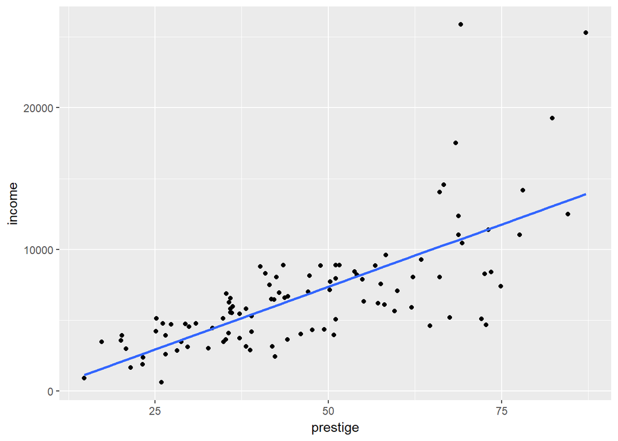

```r
# Plot of income vs prestige with linear fit
ggplot(oc_data_clean, aes(x=prestige, y=income)) +
  geom_point() +
  geom_smooth(method="lm", se=FALSE)
```

From the plot, there is a strong linear correlation between income and prestige.

### Problem 2B

Fit a model of any type we discussed in class, using all meaningful predictors of income, to obtain the “best” results, using whatever method you wish.

I will be training a random forest model.

```r
set.seed(3)

# Generate random forest model using default parameters
rf_fit <- train(income ~ .,
                data = oc_data_clean,
                method="ranger",
                na.action = na.omit)
print(rf_fit)
```

```
Random Forest

102 samples
  5 predictor

No pre-processing
Resampling: Bootstrapped (25 reps)
Summary of sample sizes: 98, 98, 98, 98, 98, 98, ...
Resampling results across tuning parameters:

  mtry  splitrule   RMSE      Rsquared   MAE
  2     variance    2662.793  0.6147523  1601.978
  2     extratrees  2573.493  0.6427322  1552.051
  4     variance    2709.708  0.6066248  1576.128
  4     extratrees  2507.977  0.6600693  1457.662
  6     variance    2794.200  0.5913997  1627.865
  6     extratrees  2516.272  0.6619215  1448.831

Tuning parameter 'min.node.size' was held constant at a value of 5
RMSE was used to select the optimal model using the smallest value.
The final values used for the model were mtry = 4, splitrule =
 extratrees and min.node.size = 5.
```

Using the “ranger” method with caret’s train function also tunes the random forest a model. The minimum RMSE value was used to choose the ideal values for mtry and splitrule.

The minimum RMSE from the Random Forest model is 2508 evaluated for the train set.

Now, let’s evaluate the RMSE for the Random Forest model against the test set.

```r
# Predict values for test
rf_pred <- predict(rf_fit, newdata=test)

# Calculate RMSE
rmse(actual = test$income, predicted = rf_pred)
```

```
[1] 2242.803
```

### Comparison

RMSE values for the two models from Problem 2A and 2B can be used to compare the effectiveness of the two models.

| Model | RMSE |
| --- | --- |
| OLSR(income ~ prestige only) | 2601 |
| Random Forest | 2243 |

The Random Forest model outperforms the OLSR model.